# Sales Forecasting using Quantitative Methods

**GOALS:**

--> Performing Time Series Analysis to understand trends and patterns in the data.

--> Testing different model for forecasting sales.

--> Choosing best model for prediction on test data.

1. Import Libraries

```python
%matplotlib inline
from matplotlib import pyplot as plt
import pandas as pd
from pandas.plotting import register_matplotlib_converters
register_matplotlib_converters()
import numpy as np
import seaborn as sns
import warnings
warnings.filterwarnings('ignore')
from statsmodels.tsa.seasonal import seasonal_decompose
from statsmodels.tsa.holtwinters import ExponentialSmoothing
from statsmodels.tsa.stattools import adfuller
from statsmodels.graphics.tsaplots import plot_acf, plot_pacf
from statsmodels.tsa.arima_model import ARIMA
from statsmodels.tsa.statespace.sarimax import SARIMAX
from sklearn.linear_model import LinearRegression
from sklearn.feature_selection import SelectKBest
from sklearn.feature_selection import f_regression
```

2. Load the Dataset

```python
df = pd.read_csv("C:\\Users\\LENOVO\\Downloads\\sales_forecasting-main\\sales_forecasting-main\\train.csv")
```

```python
df.head()
```

|  | date | store | item | sales | f0 | f1 |
| --- | --- | --- | --- | --- | --- | --- |
| 0 | 01-01-2013 | 1 | 1 | 13.0 | 9.0 | NaN |
| 1 | 02-01-2013 | 1 | 1 | 11.0 | NaN | NaN |
| 2 | 03-01-2013 | 1 | 1 | 14.0 | NaN | NaN |
| 3 | 04-01-2013 | 1 | 1 | 13.0 | NaN | NaN |
| 4 | 05-01-2013 | 1 | 1 | 10.0 | NaN | NaN |

3. Removing unwanted columns

```python
df.drop(['f0', 'f1'], axis=1, inplace=True)
```

```python
df
```

[output not shown]

913000 rows × 6 columns

4. Descriptive Statistics

```python
df.shape
```

```
(913000, 6)
```

```python
df.info()
```

[output not shown]

```python
#change data type for date column
df['date'] = df['date'].astype('datetime64[ns]')
```

```python
df.info()
```

```
<class 'pandas.core.frame.DataFrame'>
RangeIndex: 913000 entries, 0 to 912999
Data columns (total 6 columns):
 #   Column  Non-Null Count   Dtype
---  ------  --------------   -----
 0   date    913000 non-null  datetime64[ns]
 1   store   913000 non-null  int64
 2   item    913000 non-null  int64
 3   sales   912943 non-null  float64
 4   f0      41 non-null      float64
 5   f1      41 non-null      float64
dtypes: datetime64[ns](1), float64(3), int64(2)
memory usage: 41.8 MB
```

```python
df.describe()
```

|  | date | store | item | sales | f0 | f1 |
| --- | --- | --- | --- | --- | --- | --- |
| count | 913000 | 913000.000000 | 913000.000000 | 912943.000000 | 41.000000 | 41.000000 |
| mean | 2015-07-02 12:00:00.000000512 | 5.500000 | 25.500000 | 52.251626 | 5.170732 | 5.365854 |
| min | 2013-01-01 00:00:00 | 1.000000 | 1.000000 | 0.000000 | 2.000000 | 2.000000 |
| 25% | 2014-04-02 00:00:00 | 3.000000 | 13.000000 | 30.000000 | 3.000000 | 3.000000 |
| 50% | 2015-07-02 12:00:00 | 5.500000 | 25.500000 | 47.000000 | 5.000000 | 5.000000 |
| 75% | 2016-10-01 00:00:00 | 8.000000 | 38.000000 | 70.000000 | 7.000000 | 7.000000 |
| max | 2017-12-31 00:00:00 | 10.000000 | 50.000000 | 231.000000 | 9.000000 | 9.000000 |
| std | NaN | 2.872283 | 14.430878 | 28.801046 | 2.290223 | 2.556913 |

5. Missing Value Imputation

```python
df.isnull().sum()
```

```
date          0
store         0
item          0
sales        57
f0       912959
f1       912959
dtype: int64
```

```python
df = df.set_index('date')
df = df.interpolate()
```

```python
df = df.reset_index(drop=False)
df
```

|  | date | store | item | sales | f0 | f1 |
| --- | --- | --- | --- | --- | --- | --- |
| 0 | 2013-01-01 | 1 | 1 | 13.0 | 9.000000 | NaN |
| 1 | 2013-02-01 | 1 | 1 | 11.0 | 7.833333 | NaN |
| 2 | 2013-03-01 | 1 | 1 | 14.0 | 6.666667 | NaN |
| 3 | 2013-04-01 | 1 | 1 | 13.0 | 5.500000 | NaN |
| 4 | 2013-05-01 | 1 | 1 | 10.0 | 4.333333 | NaN |
| ... | ... | ... | ... | ... | ... | ... |
| 912995 | 2017-12-27 | 10 | 50 | 63.0 | 2.000000 | 5.0 |
| 912996 | 2017-12-28 | 10 | 50 | 59.0 | 2.000000 | 5.0 |
| 912997 | 2017-12-29 | 10 | 50 | 74.0 | 2.000000 | 5.0 |
| 912998 | 2017-12-30 | 10 | 50 | 62.0 | 2.000000 | 5.0 |
| 912999 | 2017-12-31 | 10 | 50 | 82.0 | 2.000000 | 5.0 |

913000 rows × 6 columns

```python
df.isnull().sum()
```

```
date       0
store      0
item       0
sales      0
f0         0
f1       176
dtype: int64
```

6. Data Preprocessing

--> Performing analysis only for rows one item and one store for this project. --> Performing train and split, with train data from January 2013 to september 2017 and test data is the data for last three months of 2017.

```python
# sort values based on date column
df.sort_values(by='date', ascending = True, inplace = True)
```

```python
# Filter records for store 1 and item 1 -> to be able to scale to other items in the future
df = df[df['store'] == 1]
df = df[df['item'] == 1]

df['date'] = pd.to_datetime(df['date'], format='%Y-%m-%d') # convert date column to datatime object

# Create Date-related Features to be used for EDA and Supervised ML: Regression
df['year'] = df['date'].dt.year
df['month'] = df['date'].dt.month
df['day'] = df['date'].dt.day
df['weekday'] = df['date'].dt.weekday
df['weekday'] = np.where(df.weekday == 0, 7, df.weekday)

# Split the series to predict the last 3 months of 2017
temp_df = df.set_index('date')
train_df = temp_df.loc[:'2017-09-30'].reset_index(drop=False)
test_df = temp_df.loc['2017-10-01':].reset_index(drop=False)
```

```python
train_df.head()
```

|  | date | store | item | sales | f0 | f1 | year | month | day | weekday |
| --- | --- | --- | --- | --- | --- | --- | --- | --- | --- | --- |
| 0 | 2013-01-01 | 1 | 1 | 13.0 | 9.000000 | NaN | 2013 | 1 | 1 | 1 |
| 1 | 2013-01-02 | 1 | 1 | 11.0 | 6.000000 | NaN | 2013 | 1 | 2 | 2 |
| 2 | 2013-01-03 | 1 | 1 | 15.0 | 6.000000 | NaN | 2013 | 1 | 3 | 3 |
| 3 | 2013-01-04 | 1 | 1 | 11.0 | 4.821053 | NaN | 2013 | 1 | 4 | 4 |
| 4 | 2013-01-05 | 1 | 1 | 16.0 | 4.505263 | NaN | 2013 | 1 | 5 | 5 |

```python
test_df.head()
```

|  | date | store | item | sales | f0 | f1 | year | month | day | weekday |
| --- | --- | --- | --- | --- | --- | --- | --- | --- | --- | --- |
| 0 | 2017-10-01 | 1 | 1 | 11.0 | 2.0 | 5.0 | 2017 | 10 | 1 | 6 |
| 1 | 2017-10-02 | 1 | 1 | 16.0 | 2.0 | 5.0 | 2017 | 10 | 2 | 7 |
| 2 | 2017-10-03 | 1 | 1 | 18.0 | 2.0 | 5.0 | 2017 | 10 | 3 | 1 |
| 3 | 2017-10-04 | 1 | 1 | 19.0 | 2.0 | 5.0 | 2017 | 10 | 4 | 2 |
| 4 | 2017-10-05 | 1 | 1 | 17.0 | 2.0 | 5.0 | 2017 | 10 | 5 | 3 |

7. Exploratory Data Analysis

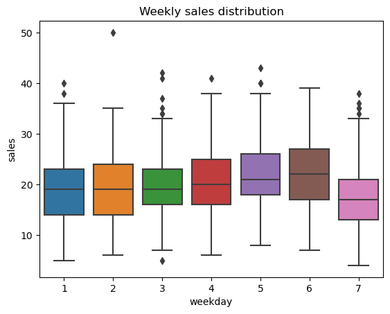

```python
plot = sns.boxplot(x='weekday', y='sales', data=df)
_ = plot.set(title='Weekly sales distribution')
```

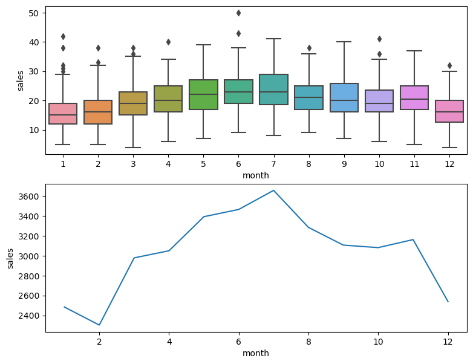

```python
# Monthly Analysis
monthly_agg = df.groupby('month')['sales'].sum().reset_index()
fig, axs = plt.subplots(nrows=2, figsize=(9,7))
sns.boxplot(x='month', y='sales', data=df, ax=axs[0])
_ = sns.lineplot(x='month', y='sales', data=monthly_agg, ax=axs[1])
```

Inference : The number of sales tend to increase in the first half except for a drop in the month of february. The highest sales take place in the month of july and then gradually decrease except for the month of november that registers good number of sales.

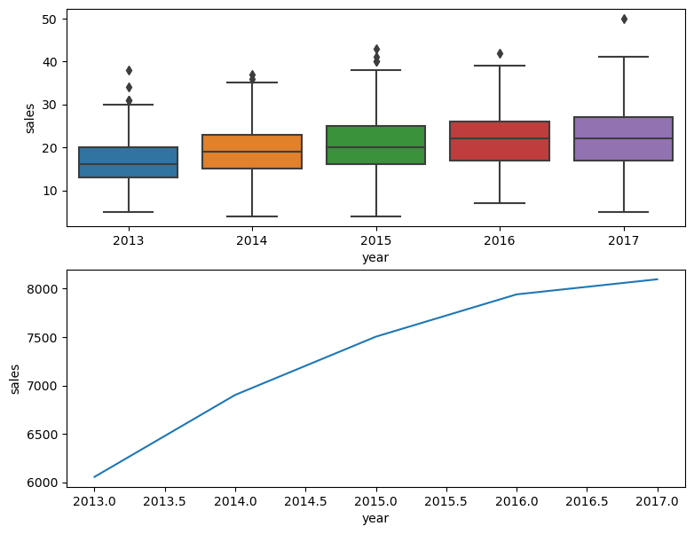

```python
# Yearly Analysis
yearly_agg = df.groupby('year')['sales'].sum().reset_index()
fig, axs = plt.subplots(nrows=2, figsize=(9,7))
sns.boxplot(x='year', y='sales', data=df, ax=axs[0])
_ = sns.lineplot(x='year', y='sales', data=yearly_agg, ax=axs[1])
```

Inference : The yearly sales analysis shows an increasing trend over the years. The sales have increased approximately from 6000 in 2013 to 8000 in 2017 with 33.33% increase in the numbers over the period of four years.

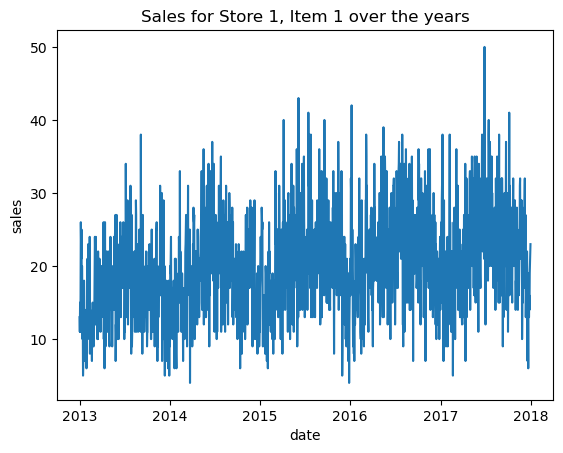

```python
plot = sns.lineplot(x='date', y='sales', data=df)
_ = plot.set(title='Sales for Store 1, Item 1 over the years')
```

Inference: There is a seasonal pattern visible in the sales over the four years. In the above lineplot the sales increase in the first half of every year, peaking in july and gradually decrease in the second half till december. This pattern is repeated for each year.

## Quantitative Methods for Sales Forecasting

It can be concluded from the exploratory data analysis performed above that the sales data contains some linear trend and seasonality. Thus, using approaches like traditional time series models as well as the casual models like Linear Regression to make prediction for the next three months and comparing the performance of both on this data.

# 1. ARIMA(Autoregressive integrated moving average) MODEL

This models combines autoregression (AR), moving average (MA), and differencing (I) to handle time series data. It does not have a seasonal element.

Step 1. Check Stationarity

Stationary is the data is a prerequisite for ARIMA model. Stationarity ensures that the statistical properties like mean,variance and autocorrelation remain constant over time.

Methods of checking stationarity are -: Plotting rolling statistics, Augmented Dickey-Fuller test and ACF and PACF plot.

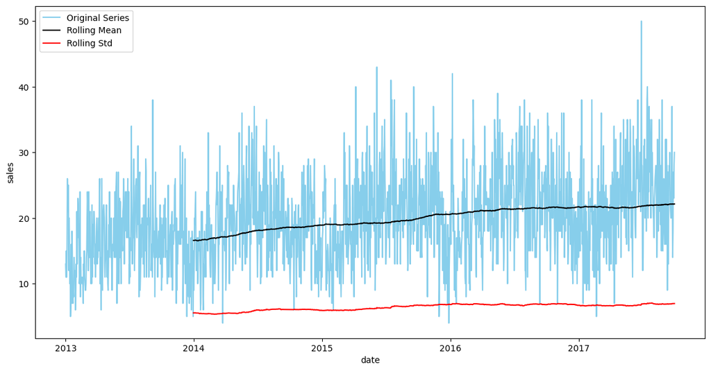

```
Test statistic = -4.640
P-value = 0.000
Critical values :
	1%: -3.434177666727206 - The data is  stationary with 99% confidence
	5%: -2.8632307003234203 - The data is  stationary with 95% confidence
	10%: -2.5676700828345895 - The data is  stationary with 90% confidence
```

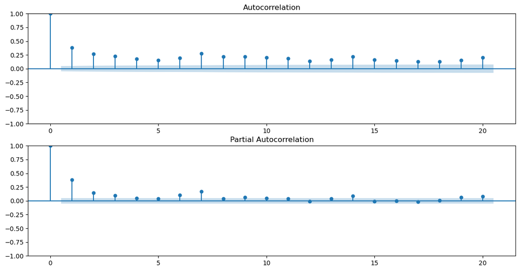

```python
arima_df = train_df[['date', 'sales']].set_index('date')
arima_test_df = test_df[['date', 'sales']].set_index('date')

def test_stationarity(timeseries):
    # Plotting rolling statistics
    rollmean = timeseries.rolling(window=365).mean()
    rollstd = timeseries.rolling(window=365).std()

    plt.figure(figsize=(14,7))
    plt.plot(timeseries, color='skyblue', label='Original Series')
    plt.plot(rollmean, color='black', label='Rolling Mean')
    plt.plot(rollstd, color='red', label='Rolling Std')
    plt.legend(loc='best')
    plt.xlabel('date')
    plt.ylabel('sales')
    plt.show()

    # Augmented Dickey-Fuller Test
    adfuller_test = adfuller(timeseries, autolag='AIC')
    print("Test statistic = {:.3f}".format(adfuller_test[0]))
    print("P-value = {:.3f}".format(adfuller_test[1]))
    print("Critical values :")

    for key, value in adfuller_test[4].items():
        print("\t{}: {} - The data is {} stationary with {}% confidence"
              .format(key, value, '' if adfuller_test[0] < value else 'not', 100-int(key[:-1])))

    # Autocorrelation Plots
    fig, ax = plt.subplots(2, figsize=(14,7))
    ax[0] = plot_acf(timeseries, ax=ax[0], lags=20)
    ax[1] = plot_pacf(timeseries, ax=ax[1], lags=20)

test_stationarity(arima_df.sales)
```

Step 2. Differencing

Differencing can help stabilise the mean of a time series by removing changes in the level of a time series, and therefore eliminating (or reducing) trend and seasonality. Seasonal or cyclical patterns can be removed by substracting periodical values. If the data is 12-month seasonal, substracting the series with a 12-lag difference series will give a “flatter” series. Since we have aggregated the data to each day-level, we will shift by 1.

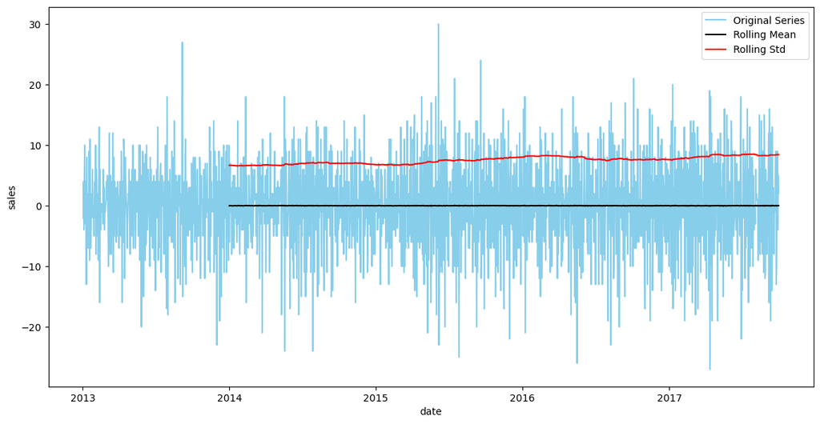

```
Test statistic = -13.661
P-value = 0.000
Critical values :
	1%: -3.4341866496114535 - The data is  stationary with 99% confidence
	5%: -2.8632346655630943 - The data is  stationary with 95% confidence
	10%: -2.567672194245481 - The data is  stationary with 90% confidence
```

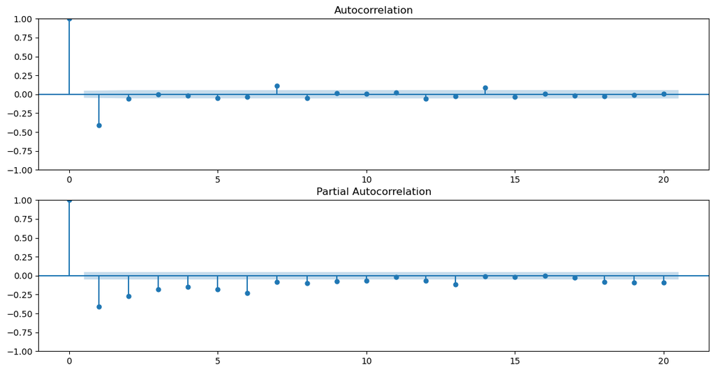

```python
first_difference = arima_df.sales - arima_df.sales.shift(1)
first_difference = pd.DataFrame(first_difference.dropna(inplace=False))

# Check for stationarity after differencing
test_stationarity(first_difference.sales)
```

Inference: After applying Differencing to the series, we can see from the above results that the series is now stationary, i.e. mean and variance are constant over time.

Step 3. Model Building

Interpreting the AR(p), I(d), MA(q) values:

1. **Determining I(d):**

   Taking the first order difference makes the time series stationary. Therefore, **I(d) = 1.**
2. **Determining AR(p):** If the lag-1 autocorrelation of the differenced series PACF is negative, and/or there is a sharp cutoff, then choose a AR order of 1.

   From the PACF plot we can clearly observe that within 6 lags the AR is significant. Therefore, we can use **AR(p) = 6**, (6 lines are crossed the blue lines so 6past days are required to predict).
3. **Determining MA(q):** If the lag-1 autocorrelation of the differenced series ACF is negative, and/or there is a sharp cutoff, then choose a MA order of 1.

   From tha ACF plot we see a negative spike at lag 1, therfore we can use **MA(q) = 1**

```python
from statsmodels.tsa.arima.model import ARIMA

arima_model = ARIMA(arima_df['sales'], order=(6, 1, 1))
arima_fit = arima_model.fit()

print(arima_fit.summary())
```

```
                               SARIMAX Results
==============================================================================
Dep. Variable:                  sales   No. Observations:                 1734
Model:                 ARIMA(6, 1, 1)   Log Likelihood               -5556.476
Date:                Fri, 10 Jan 2025   AIC                          11128.951
Time:                        12:46:34   BIC                          11172.612
Sample:                    01-01-2013   HQIC                         11145.099
                         - 09-30-2017
Covariance Type:                  opg
==============================================================================
                 coef    std err          z      P>|z|      [0.025      0.975]
------------------------------------------------------------------------------
ar.L1          0.2058      0.025      8.125      0.000       0.156       0.255
ar.L2          0.0293      0.025      1.180      0.238      -0.019       0.078
ar.L3          0.0077      0.025      0.312      0.755      -0.041       0.056
ar.L4         -0.0332      0.025     -1.307      0.191      -0.083       0.017
ar.L5         -0.0546      0.025     -2.203      0.028      -0.103      -0.006
ar.L6          0.0131      0.024      0.548      0.584      -0.034       0.060
ma.L1         -0.9558      0.009   -108.293      0.000      -0.973      -0.939
sigma2        35.6381      1.132     31.471      0.000      33.419      37.858
===================================================================================
Ljung-Box (L1) (Q):                   0.01   Jarque-Bera (JB):                21.39
Prob(Q):                              0.93   Prob(JB):                         0.00
Heteroskedasticity (H):               1.42   Skew:                             0.22
Prob(H) (two-sided):                  0.00   Kurtosis:                         3.31
===================================================================================

Warnings:
[1] Covariance matrix calculated using the outer product of gradients (complex-step).
```

step 4. Plotting the residuals using ACF and PACF

Plotting the residuals shows that recurring correlation exists in both ACF and PACF. So we need to deal with seasonality. When the plots of ACF and PACF are similar or any sesaonality is present between them then, we will need to apply the Seasonal ARIMA (SARIMA) model.

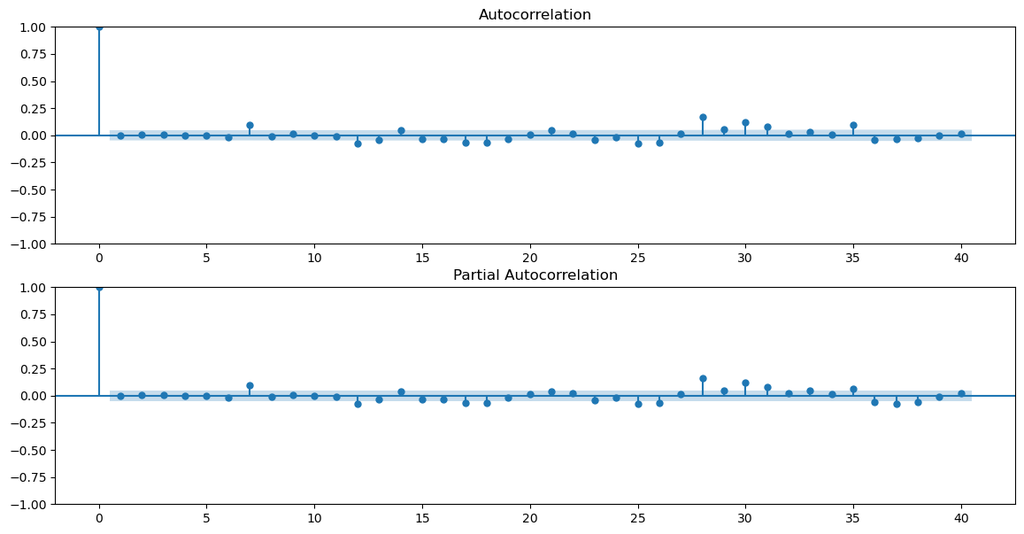

```python
from statsmodels.tsa.arima.model import ARIMA
from statsmodels.graphics.tsaplots import plot_acf, plot_pacf

arima_model = ARIMA(arima_df['sales'], order=(6, 1, 1))
arima_fit = arima_model.fit()

residuals = arima_fit.resid

# Checking for seasonality
fig, ax = plt.subplots(2, figsize=(14,7))
ax[0] = plot_acf(residuals, ax=ax[0], lags=40)
ax[1] = plot_pacf(residuals, ax=ax[1], lags=40)
```

# 2. SARIMA(Seasonal Autoregressive integrated moving average) MODEL

SARIMA is seasonal ARIMA i.e with a seasonal component.

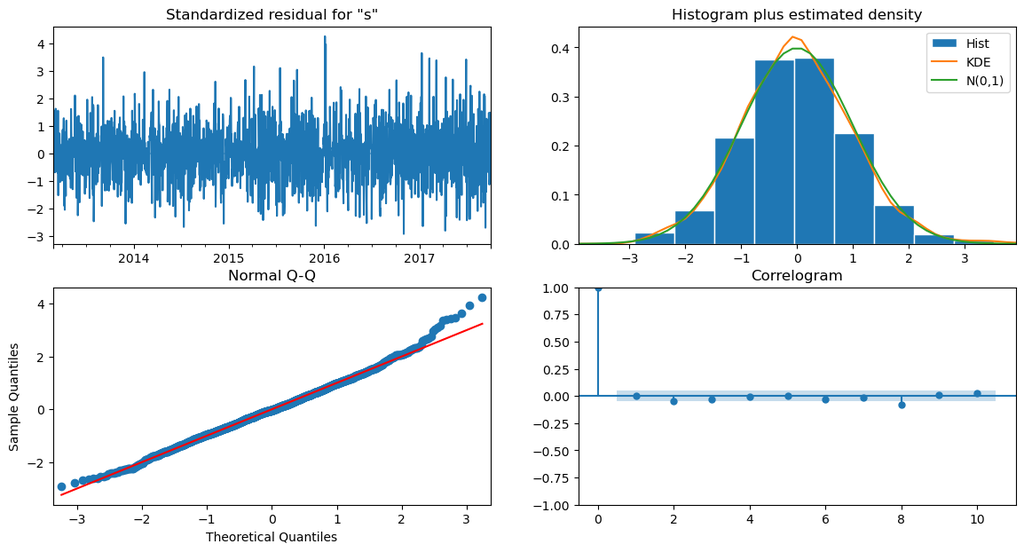

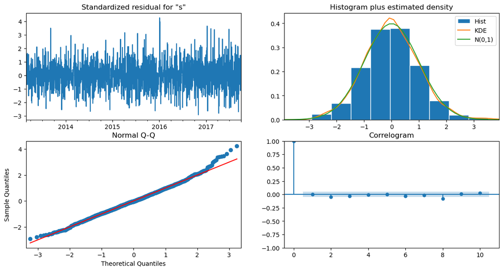

```python
# fit the model
sarima_model = SARIMAX(arima_df.sales, order=(6, 1, 0), seasonal_order=(6, 1, 0, 7),
                       enforce_invertibility=False, enforce_stationarity=False)
sarima_fit = sarima_model.fit()
arima_test_df['pred_sales'] = sarima_fit.predict(start=arima_test_df.index[0],
                                                 end=arima_test_df.index[-1], dynamic= True)
plot = sarima_fit.plot_diagnostics(figsize=(14,7))
plot
```

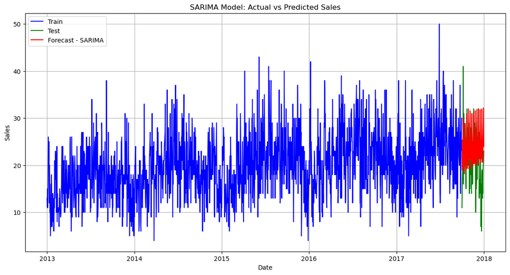

```python
import matplotlib.pyplot as plt
import numpy as np

# Plot the training, test, and predicted sales
plt.figure(figsize=(14, 7))

# Training data
plt.plot(arima_df.index, arima_df.sales, label='Train', color='blue')

# Test data
plt.plot(arima_test_df.index, arima_test_df.sales, label='Test', color='green')

# Predicted data
plt.plot(arima_test_df.index, arima_test_df.pred_sales, label='Forecast - SARIMA', color='red')

# Add labels, title, and legend
plt.legend(loc='best')
plt.xlabel('Date')
plt.ylabel('Sales')
plt.title('SARIMA Model: Actual vs Predicted Sales')
plt.grid()
plt.show()
```

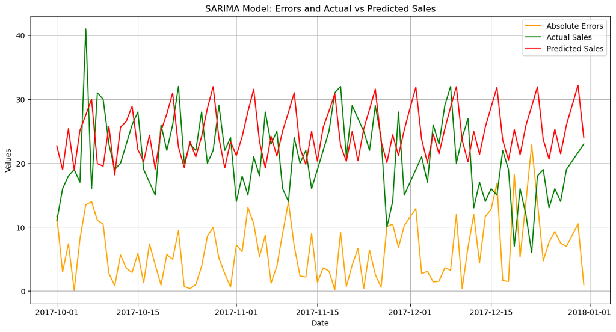

```python
# Calculate Absolute Errors
arima_test_df['abs_errors'] = np.abs(arima_test_df.sales - arima_test_df.pred_sales)

# Plot errors vs. actual sales and predicted sales
plt.figure(figsize=(14, 7))

# Absolute errors
plt.plot(arima_test_df.index, arima_test_df.abs_errors, label='Absolute Errors', color='orange')

# Actual sales
plt.plot(arima_test_df.index, arima_test_df.sales, label='Actual Sales', color='green')

# Predicted sales
plt.plot(arima_test_df.index, arima_test_df.pred_sales, label='Predicted Sales', color='red')

# Add labels, title, and legend
plt.legend(loc='best')
plt.xlabel('Date')
plt.ylabel('Values')
plt.title('SARIMA Model: Errors and Actual vs Predicted Sales')
plt.grid()
plt.show()
```

```python
# Define evaluation metrics
def mae(y_true, y_pred):
    return np.mean(np.abs(y_true - y_pred))

def rmse(y_true, y_pred):
    return np.sqrt(np.mean((y_true - y_pred) ** 2))

def mape(y_true, y_pred):
    return np.mean(np.abs((y_true - y_pred) / y_true)) * 100

# Calculate metrics
mae_value = mae(arima_test_df.sales, arima_test_df.pred_sales)
rmse_value = rmse(arima_test_df.sales, arima_test_df.pred_sales)
mape_value = mape(arima_test_df.sales, arima_test_df.pred_sales)

# Display metrics
print(f"Mean Absolute Error (MAE): {mae_value:.2f}")
print(f"Root Mean Squared Error (RMSE): {rmse_value:.2f}")
print(f"Mean Absolute Percentage Error (MAPE): {mape_value:.2f}%")
```

```
Mean Absolute Error (MAE): 6.46
Root Mean Squared Error (RMSE): 8.02
Mean Absolute Percentage Error (MAPE): 39.95%
```

```python
import pandas as pd

# Create a summary DataFrame
result_summary = pd.DataFrame({
    'Model': ['SARIMA'],
    'MAE': [mae_value],
    'RMSE': [rmse_value],
    'MAPE (%)': [mape_value]
})

print(result_summary)
```

```
    Model       MAE      RMSE   MAPE (%)
0  SARIMA  6.458553  8.023419  39.946703
```

# 3. Linear Regression (ML Model)

```python
reg_df = df
reg_df
```

|  | date | store | item | sales | f0 | f1 | year | month | day | weekday |
| --- | --- | --- | --- | --- | --- | --- | --- | --- | --- | --- |
| 0 | 2013-01-01 | 1 | 1 | 13.000000 | 9.000000 | NaN | 2013 | 1 | 1 | 1 |
| 31 | 2013-01-02 | 1 | 1 | 11.000000 | 6.000000 | NaN | 2013 | 1 | 2 | 2 |
| 59 | 2013-01-03 | 1 | 1 | 15.000000 | 6.000000 | NaN | 2013 | 1 | 3 | 3 |
| 90 | 2013-01-04 | 1 | 1 | 11.000000 | 4.821053 | NaN | 2013 | 1 | 4 | 4 |
| 120 | 2013-01-05 | 1 | 1 | 16.000000 | 4.505263 | NaN | 2013 | 1 | 5 | 5 |
| ... | ... | ... | ... | ... | ... | ... | ... | ... | ... | ... |
| 1821 | 2017-12-27 | 1 | 1 | 14.000000 | 2.000000 | 5.0 | 2017 | 12 | 27 | 2 |
| 1822 | 2017-12-28 | 1 | 1 | 19.000000 | 2.000000 | 5.0 | 2017 | 12 | 28 | 3 |
| 1823 | 2017-12-29 | 1 | 1 | 20.333333 | 2.000000 | 5.0 | 2017 | 12 | 29 | 4 |
| 1824 | 2017-12-30 | 1 | 1 | 21.666667 | 2.000000 | 5.0 | 2017 | 12 | 30 | 5 |
| 1825 | 2017-12-31 | 1 | 1 | 23.000000 | 2.000000 | 5.0 | 2017 | 12 | 31 | 6 |

1826 rows × 10 columns

Step 1. Feature Engineering

```python
# Lag features
for i in range(1,8):
    lag_i = 'lag_' + str(i)
    reg_df[lag_i] = reg_df.sales.shift(i)

# Rolling window
reg_df['rolling_mean'] = reg_df.sales.rolling(window=7).mean()
reg_df['rolling_max'] = reg_df.sales.rolling(window=7).max()
reg_df['rolling_min'] = reg_df.sales.rolling(window=7).min()

reg_df = reg_df.dropna(how='any', inplace=False)
reg_df = reg_df.drop(['store', 'item'], axis=1)

# Split the series to predict the last 3 months of 2017
reg_df = reg_df.set_index('date')
reg_train_df = reg_df.loc[:'2017-09-30']
reg_test_df = reg_df.loc['2017-10-01':]
```

Step 2. Feature Selection and Model Building

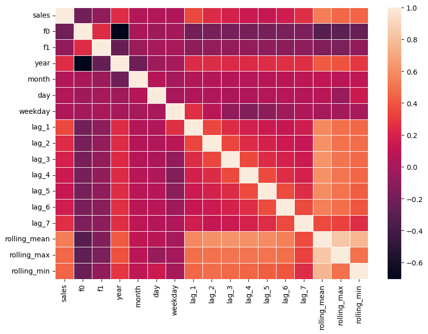

```python
# Correlation matrix with heatmap
corr = reg_train_df.corr()
fig = plt.figure(figsize=(10,7))
_ = sns.heatmap(corr, linewidths=.5)
```

```python
X_train = reg_train_df.drop(['sales'], axis=1)
y_train = reg_train_df['sales'].values

X_test = reg_test_df.drop(['sales'], axis=1)
y_test = reg_test_df['sales'].values

#Univariate SelectKBest class to extract top 5 best features
top_features = SelectKBest(score_func=f_regression, k=5)
fit = top_features.fit(X_train, y_train)
df_scores = pd.DataFrame(fit.scores_)
df_columns = pd.DataFrame(X_train.columns)

#concat two dataframes for better visualization
feature_scores = pd.concat([df_columns, df_scores], axis=1)
feature_scores.columns = ['Feature','Score']  # naming the dataframe columns
print(feature_scores.nlargest(5,'Score'))  # print 5 best features
```

```
         Feature       Score
13  rolling_mean  640.584525
14   rolling_max  404.243873
15   rolling_min  382.820679
6          lag_1  219.123569
12         lag_7  109.099259
```

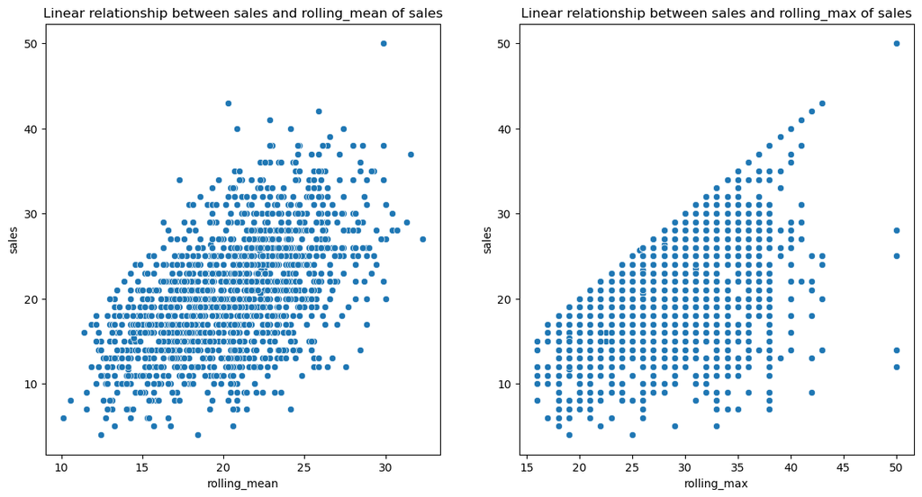

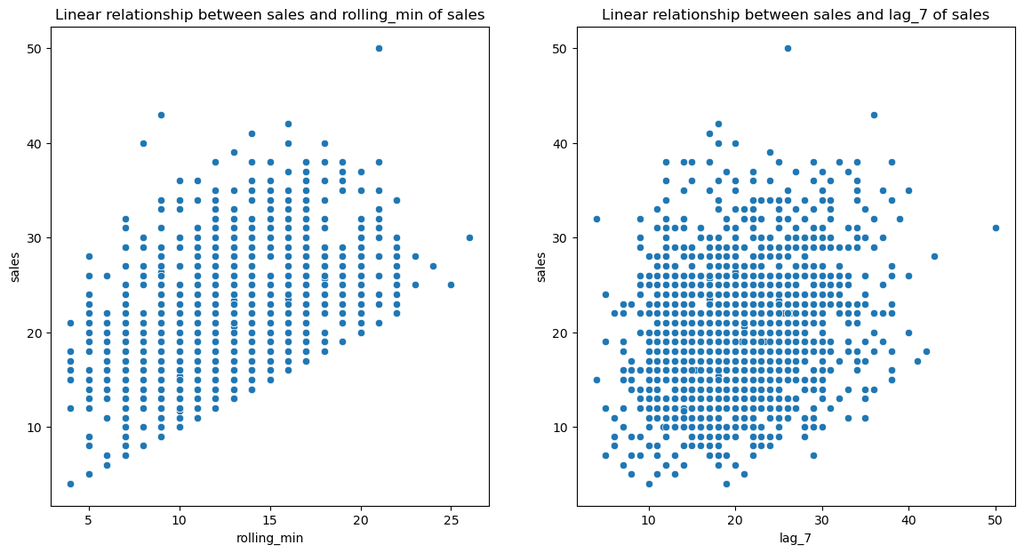

```python
# Checking for a linear relationship of the top features with sales (target variable)

fig, axs = plt.subplots(ncols=2, figsize=(14,7))
sns.scatterplot(x=reg_train_df['rolling_mean'], y=reg_train_df['sales'], ax=axs[0])
axs[0].set(title='Linear relationship between sales and rolling_mean of sales')
sns.scatterplot(x=reg_train_df['rolling_max'], y=reg_train_df['sales'], ax=axs[1])
axs[1].set(title='Linear relationship between sales and rolling_max of sales')

fig, axs = plt.subplots(ncols=2, figsize=(14,7))
sns.scatterplot(x=reg_train_df['rolling_min'], y=reg_train_df['sales'], ax=axs[0])
axs[0].set(title='Linear relationship between sales and rolling_min of sales')
sns.scatterplot(x=reg_train_df['lag_7'], y=reg_train_df['sales'], ax=axs[1])
axs[1].set(title='Linear relationship between sales and lag_7 of sales')

plt.show()
```

```python
# update X_train, X_test to include top features
X_train = X_train[['rolling_mean', 'rolling_max', 'rolling_min', 'lag_7', 'lag_1']]
X_test = X_test[['rolling_mean', 'rolling_max', 'rolling_min', 'lag_7', 'lag_1']]

# fit model
model = LinearRegression()
model.fit(X_train, y_train)

preds = model.predict(X_test)

errors_df = reg_test_df[['sales']]
errors_df['pred_sales'] = preds
errors_df['errors'] = preds - y_test
errors_df.insert(0, 'model', 'LinearRegression')
```

Step 3. Model evaluation and Prediction

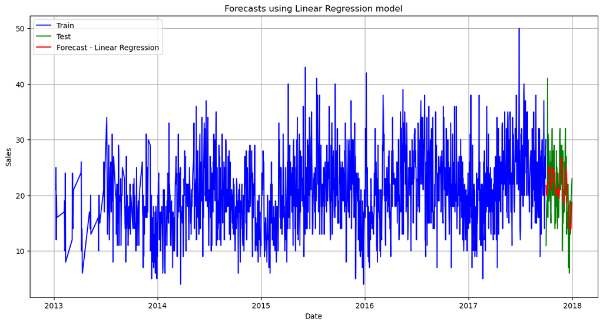

```python
#import matplotlib.pyplot as plt
import matplotlib.pyplot as plt

# Plot Actual vs Predicted Sales
plt.figure(figsize=(14, 7))

# Training data
plt.plot(reg_train_df.index, reg_train_df['sales'], label='Train', color='blue')

# Test data
plt.plot(reg_test_df.index, reg_test_df['sales'], label='Test', color='green')

# Predicted sales
plt.plot(errors_df.index, errors_df['pred_sales'], label='Forecast - Linear Regression', color='red')

# Add labels, legend, and title
plt.legend(loc='best')
plt.xlabel('Date')
plt.ylabel('Sales')
plt.title('Forecasts using Linear Regression model')
plt.grid()
plt.show()
```

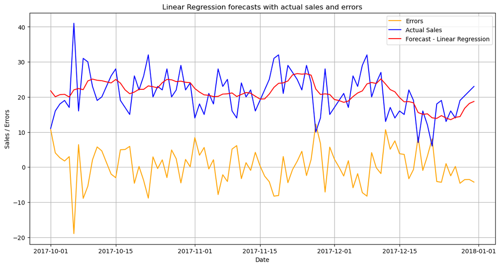

```python
# Plot Errors, Actual Sales, and Forecast
plt.figure(figsize=(14, 7))

# Errors
plt.plot(errors_df.index, errors_df['errors'], label='Errors', color='orange')

# Actual sales
plt.plot(errors_df.index, errors_df['sales'], label='Actual Sales', color='blue')

# Predicted sales
plt.plot(errors_df.index, errors_df['pred_sales'], label='Forecast - Linear Regression', color='red')

# Add labels, legend, and title
plt.legend(loc='best')
plt.xlabel('Date')
plt.ylabel('Sales / Errors')
plt.title('Linear Regression forecasts with actual sales and errors')
plt.grid()
plt.show()
```

```python
import numpy as np

# Mean Absolute Error
def mae(y_true, y_pred):
    return np.mean(np.abs(y_true - y_pred))

# Root Mean Squared Error
def rmse(y_true, y_pred):
    return np.sqrt(np.mean((y_true - y_pred) ** 2))

# Mean Absolute Percentage Error
def mape(y_true, y_pred):
    return np.mean(np.abs((y_true - y_pred) / y_true)) * 100
```

```python
# Extract actual and predicted values
y_true = errors_df['sales']
y_pred = errors_df['pred_sales']

# Calculate metrics
mae_value = mae(y_true, y_pred)
rmse_value = rmse(y_true, y_pred)
mape_value = mape(y_true, y_pred)

# Display metrics
print(f"Mean Absolute Error (MAE): {mae_value:.2f}")
print(f"Root Mean Squared Error (RMSE): {rmse_value:.2f}")
print(f"Mean Absolute Percentage Error (MAPE): {mape_value:.2f}%")
```

```
Mean Absolute Error (MAE): 4.19
Root Mean Squared Error (RMSE): 5.20
Mean Absolute Percentage Error (MAPE): 23.43%
```

```python
import pandas as pd

# Create a summary DataFrame
result_summary = pd.DataFrame({
    'Model': ['Linear Regression'],
    'MAE': [mae_value],
    'RMSE': [rmse_value],
    'MAPE (%)': [mape_value]
})

print(result_summary)
```

```
               Model       MAE     RMSE   MAPE (%)
0  Linear Regression  4.189609  5.20455  23.428997
```

Inference: The Linear regression model captures the upwards as well as the downwards movement in the sales data. Its performance, **MAPE 23.4%** , is better than the time series models **MAPE 39.9%** and which was the best performing model so far.